# Modeling and prediction for movies

Schwinn Chen

June 21, 2017

## Part 1: Data

The data set is comprised of 651 randomly sampled movies produced and released before 2016. Because random samples are used in this analysis. The conclusions from this analysis can be generalized to US population. As no random assignment was conducted in the sampling, we can only draw observational (non-causal) conclusions from this report.

## Part 2: Research question

We are interested in predicting the ratings of movies based on a number of movie features. The data set contains 32 variables (refer to the movies code book for details of the variables). We will redefine our research question more clearly as we learn more about the variables in the section of Exploratory Data Analysis.

## Part 3: Exploratory data analysis

# Load packages

```r
library(dplyr)
library(statsr)
library(ggplot2)
```

```r
#load dataset
load("movies.Rdata")
```

The dataset consists of 32 variables. We exclude variables that 1) do not provide meaningful prediction 2) randomly related to movie ratings 3) provide redundant or collinear information. 4) do not meet linear regression conditions

### 1) do not provide meaningful prediction

For example, variable “studio” indicates the studio that produced the movie. Using the following R code, we find that there are 212 categories in “studio”, too many to provide meaningful prediction.

```r
movies%>%
group_by(studio)%>%
summarise(count=n())
```

```
## # A tibble: 212 x 2
##    studio                            count
##    <fct>                             <int>
##  1 20th Century Fox                     18
##  2 20th Century Fox Film Corporat        2
##  3 20th Century Fox Film Corporation     5
##  4 7-57 Releasing                        1
##  5 7th art                               1
##  6 905 Corporation                       1
##  7 A24                                   1
##  8 A24 Films                             2
##  9 All Girl Productions                  1
## 10 Alliance Atlantis Communications      1
## # ... with 202 more rows
```

### 2) randomly related to movie ratings

We find that the following variables have random relation to movie ratings: thtr_rel_year, thtr_rel_month, thtr_rel_day, dvd_rel_year, dvd_rel_month, dvd_rel_day. For example, “dvd_rel_month” tells us the month the movie was released on DVD. We can plot a scatter chart to see the relation between “dvd_rel_month” (explanatory) and “imdb_rating” (response). The chart indicates that “dvd_rel_month” and “imdb_rating” are not correlated, therefore, “dvd_rel_month” will not provide meaningful information about the IMDB ratings. Similarly, we exclude “thtr_rel_year”, “thtr_rel_month”, “thtr_rel_day”, “dvd_rel_year”, and “dvd_rel_dayIn”.

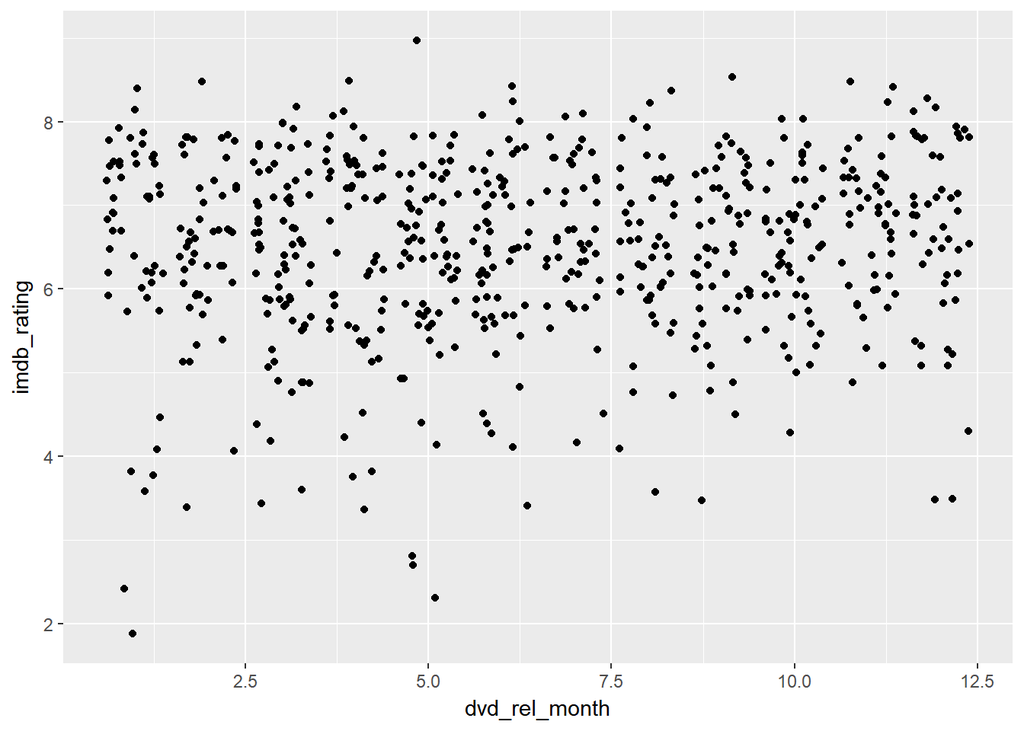

```r
#plot distribution of month vs. imdb_rating
ggplot(movies, aes(x=dvd_rel_month, y=imdb_rating))+geom_jitter()
```

### 3) provide redundant or collinear information

We find that the following variables are paired.

“critics_rating” and “critics_score” “critics_rating” is a categorical variable for critics rating on Rotten Tomatoes (Certified Fresh, Fresh, Rotten) and “critics_score” is its numerical counterpart. These two variables tells redundant information. We will keep the numerical variable “critics_score” and discard “critics_rating”.

In a similar fashion, we keep “audience_score” and discard “audience_rating”.

### 4) remove numberical variables that do not meet linear regression conditions.

Now have four numerical variables in our model “runtime”, “imdb_num_votes”, “critics_score” and “audience_score”. We need to find whether these variables meet the conditions for linear regression before we include them in our model.

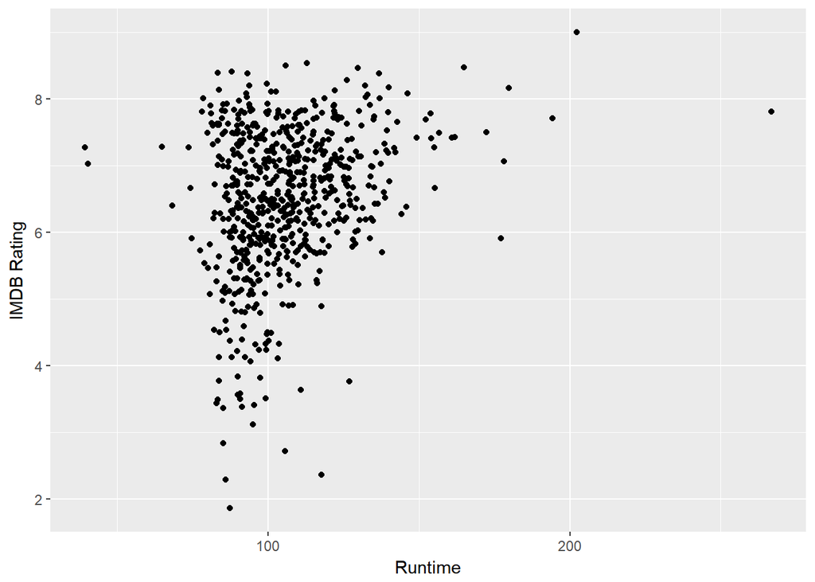

```r
#plot scattered plot to find whether runtime or imdb_num_votes correlates to imdb_rating
ggplot(movies, aes(x=runtime, y=imdb_rating))+geom_jitter()+xlab("Runtime")+ylab("IMDB Rating")
```

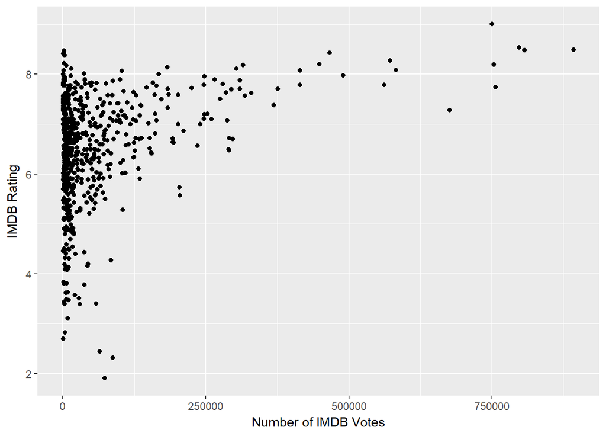

```r
ggplot(movies, aes(x=imdb_num_votes, y=imdb_rating))+geom_jitter()+xlab("Number of IMDB Votes")+ylab("IMDB Rating")
```

4.1) regression modeling of ‘imdb_rating’ with respect to ‘runtime’

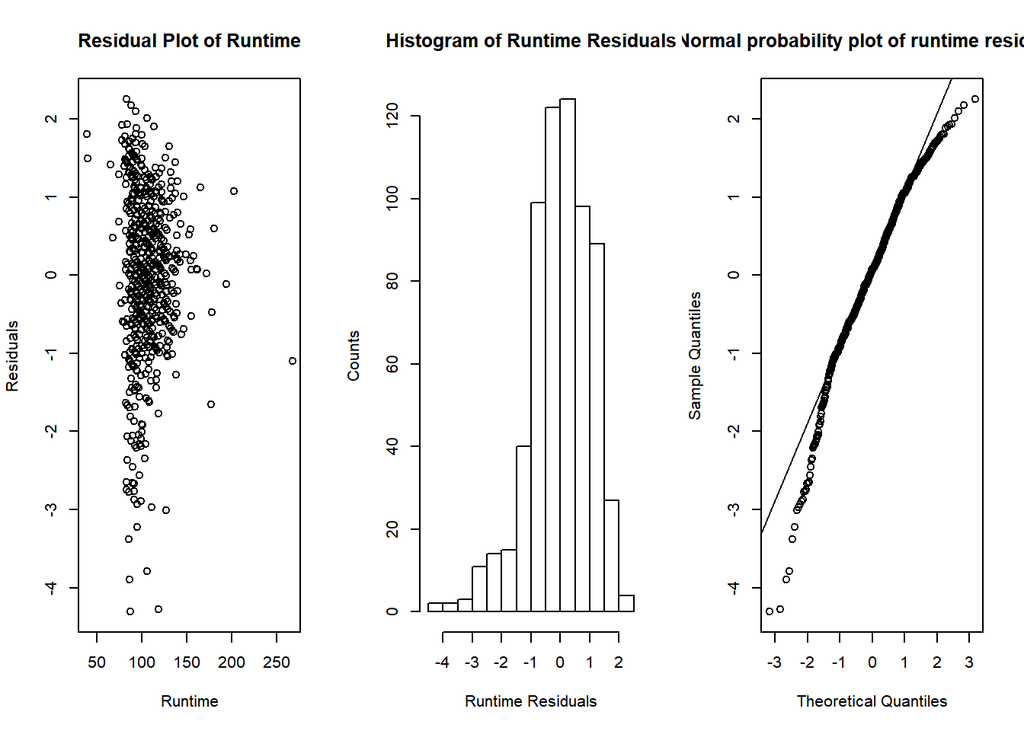

```r
# remove NA data
movies<-movies%>%
  filter(!is.na(runtime))%>%
  filter(!is.na(imdb_num_votes))%>%
  filter(!is.na(critics_score))
#residual plot, histogram and Quantile-Quantile plot of runtime.
runtime<-lm(imdb_rating~runtime, data=movies)
par(mfrow=c(1,3))
#residuals plot x=runtime
plot(runtime$residuals~movies$runtime, main="Residual Plot of Runtime", xlab="Runtime", ylab="Residuals")
hist(runtime$residuals,main="Histogram of Runtime Residuals", xlab="Runtime Residuals", ylab="Counts") #histogram of residuals
qqnorm(runtime$residuals, main="Normal probability plot of runtime residuals") # Normal QQ plot of residuals
qqline(runtime$residuals)
```

From the above residual plot, histogram and Quantile-Quantile plot of runtime, we can see that the residuals are not distributed normally around 0 (left skewed) at constant variance. Therefore, ‘runtime’ will not predict reliable prediction and we will not include it in our model.

4.2) regression modeling of ‘imdb_rating’ with respect to ‘imdb_num_votes’

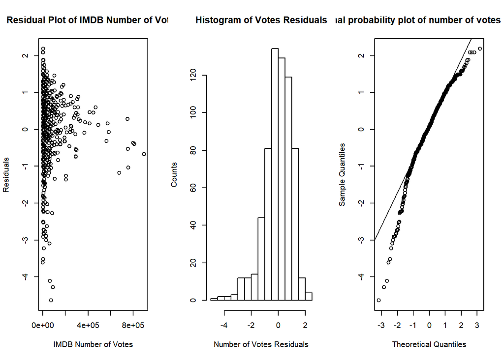

```r
#residual plot, histogram and Quantile-Quantile plot of 'imdb_num_votes'.
imdb_num_votes<-lm(imdb_rating~imdb_num_votes, data=movies)
par(mfrow=c(1,3))
#residuals plot x=imdb_num_votes
plot(imdb_num_votes$residuals~movies$imdb_num_votes, main="Residual Plot of IMDB Number of Votes", xlab="IMDB Number of Votes", ylab="Residuals")
hist(imdb_num_votes$residuals,main="Histogram of Votes Residuals", xlab="Number of Votes Residuals", ylab="Counts") #histogram of residuals
qqnorm(imdb_num_votes$residuals, main="Normal probability plot of number of votes residuals") # Normal QQ plot of residuals
qqline(imdb_num_votes$residuals)
```

From the above residual plot, histogram and Quantile-Quantile plot of runtime, we can see that the residuals are not distributed normally around 0 (left skewed) at constant variance. Therefore, ‘imdb_num_votes’ will not predict reliable prediction and we will not include it in our model.

4.3) regression modeling of ‘imdb_rating’ with respect to ‘audience_score’

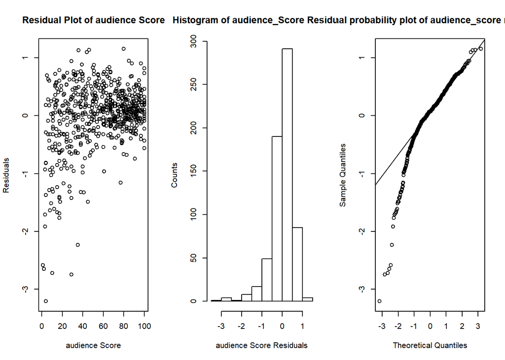

```r
#residual plot, histogram and Quantile-Quantile plot of 'audience_score'.
audience_score<-lm(imdb_rating~audience_score, data=movies)
par(mfrow=c(1,3))
#residuals plot x=audience_score

plot(audience_score$residuals~movies$critics_score, main="Residual Plot of audience Score", xlab="audience Score", ylab="Residuals")
hist(audience_score$residuals,main="Histogram of audience_Score Residuals", xlab="audience Score Residuals", ylab="Counts") #histogram of residuals
qqnorm(audience_score$residuals, main="Normal probability plot of audience_score residuals") # Normal QQ plot of residuals
qqline(audience_score$residuals)
```

From the above residual plot, histogram and Quantile-Quantile plot of runtime, we can see that the residuals are not distributed normally around 0 (left skewed) at constant variance. Therefore, ‘audience_score’ will not predict reliable prediction and we will not include it in our model.

5.3) regression modeling of ‘imdb_rating’ with respect to ‘critics_score’

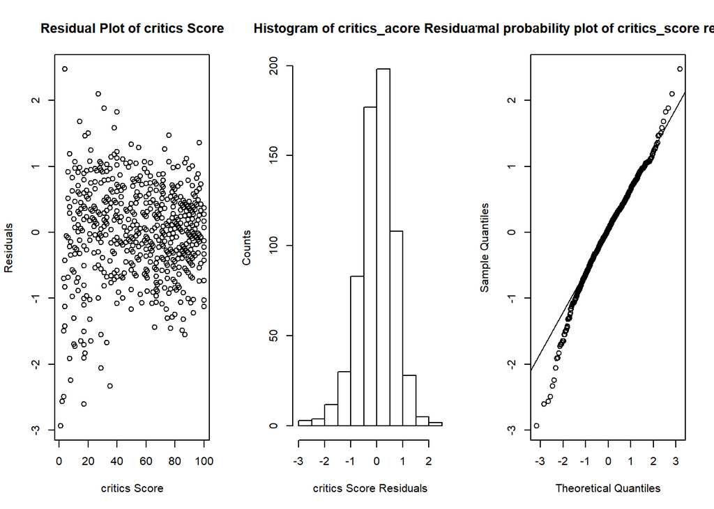

```r
#residual plot, histogram and Quantile-Quantile plot of 'critics_score'.
critics_score<-lm(imdb_rating~critics_score, data=movies)
par(mfrow=c(1,3))
#residuals plot x=critics_score

plot(critics_score$residuals~movies$critics_score, main="Residual Plot of critics Score", xlab="critics Score", ylab="Residuals")
hist(critics_score$residuals,main="Histogram of critics_acore Residuals", xlab="critics Score Residuals", ylab="Counts") #histogram of residuals
qqnorm(critics_score$residuals, main="Normal probability plot of critics_score residuals") # Normal QQ plot of residuals
qqline(critics_score$residuals)
```

From the above residual plot, histogram and Quantile-Quantile plot of runtime, we can see that the residuals are nearly normal distributed around 0 at constant variance. Therefore, we will use ‘critics_score’ in our model.

## Redefined Research Question

We will create a statistical model to predict the IMDB ratings of a movie based on 651 movies released before 2016. ‘imdb_rating’ is the response variable.  
We consider ten explanatory variables: “title_type”, “genre”, “mpaa_rating”,“critics_score”, “best_pic_nom”, “best_pic_win”, “best_actor_win”, “best_actress_win”, “best_dir_win”, “top200_box”.

## Part 4: Modeling

In the Part 4 (Modeling), we will find the parsimonious model that include the simplest variables. We have one numerical variable “critics_score” and nine categorical variables.

```r
#linear regression in all variables and store in "full_model"
full_model<-lm(imdb_rating~title_type+genre+mpaa_rating+critics_score+best_pic_nom+best_pic_win+best_actor_win+best_actress_win+best_dir_win+top200_box, data=movies)
summary(full_model)
```

```
##
## Call:
## lm(formula = imdb_rating ~ title_type + genre + mpaa_rating +
##     critics_score + best_pic_nom + best_pic_win + best_actor_win +
##     best_actress_win + best_dir_win + top200_box, data = movies)
##
## Residuals:
##      Min       1Q   Median       3Q      Max
## -2.80032 -0.37635  0.05265  0.40161  1.98892
##
## Coefficients:
##                                 Estimate Std. Error t value Pr(>|t|)
## (Intercept)                     4.973493   0.322834  15.406   <2e-16 ***
## title_typeFeature Film         -0.003509   0.252194  -0.014   0.9889
## title_typeTV Movie             -0.522499   0.395306  -1.322   0.1867
## genreAnimation                 -0.306360   0.264125  -1.160   0.2465
## genreArt House & International  0.401825   0.204217   1.968   0.0496 *
## genreComedy                    -0.206651   0.112532  -1.836   0.0668 .
## genreDocumentary                0.587253   0.268328   2.189   0.0290 *
## genreDrama                      0.140224   0.098847   1.419   0.1565
## genreHorror                    -0.283949   0.167548  -1.695   0.0906 .
## genreMusical & Performing Arts  0.445263   0.230026   1.936   0.0534 .
## genreMystery & Suspense         0.106836   0.126907   0.842   0.4002
## genreOther                      0.056752   0.192587   0.295   0.7683
## genreScience Fiction & Fantasy -0.451518   0.240331  -1.879   0.0607 .
## mpaa_ratingNC-17               -0.552160   0.512073  -1.078   0.2813
## mpaa_ratingPG                  -0.164234   0.186086  -0.883   0.3778
## mpaa_ratingPG-13               -0.088548   0.190324  -0.465   0.6419
## mpaa_ratingR                   -0.031767   0.184709  -0.172   0.8635
## mpaa_ratingUnrated             -0.148258   0.211295  -0.702   0.4831
## critics_score                   0.025534   0.001113  22.933   <2e-16 ***
## best_pic_nomyes                 0.399043   0.174101   2.292   0.0222 *
## best_pic_winyes                 0.070427   0.307484   0.229   0.8189
## best_actor_winyes               0.045228   0.079023   0.572   0.5673
## best_actress_winyes             0.033411   0.088504   0.378   0.7059
## best_dir_winyes                 0.134692   0.115098   1.170   0.2424
## top200_boxyes                   0.217046   0.182751   1.188   0.2354
## ---
## Signif. codes:  0 '***' 0.001 '**' 0.01 '*' 0.05 '.' 0.1 ' ' 1
##
## Residual standard error: 0.6739 on 625 degrees of freedom
## Multiple R-squared:  0.6284, Adjusted R-squared:  0.6141
## F-statistic: 44.04 on 24 and 625 DF,  p-value: < 2.2e-16
```

Now, our model has ten explanatory variables: “title_type”, “genre”, “mpaa_rating”,“critics_score”, best_pic_nom“,”best_dir_win“,”best_pic_win“,”best_actor_win“,”best_actress_win" and “top200_box”. Because we have ten explanatory variables, we choose the forward selection approach. We will conduct our selection using adjusted R^2 method because it is more reliable than the p-value method.

```r
#calulate adjusted R^2 for each explanatory variable

title_type<-lm(imdb_rating ~ title_type, data = movies)
paste("The adj. R sqr for 'title_type' is", summary(title_type)$adj.r.squared)
genre<-lm(imdb_rating ~ genre, data = movies)
paste("The adj. R sqr for 'genre' is", summary(genre)$adj.r.squared)
mpaa_rating<-lm(imdb_rating ~ mpaa_rating, data = movies)
paste("The adj. R sqr for 'mpaa_rating' is",summary(mpaa_rating)$adj.r.squared)
critics_score<-lm(imdb_rating ~ critics_score, data = movies)
paste("The adj. R sqr for 'critics_score' is",summary(critics_score)$adj.r.squared)
best_pic_nom<-lm(imdb_rating ~ best_pic_nom, data = movies)
paste("The adj. R sqr for 'best_pic_nom' is",summary(best_pic_nom)$adj.r.squared)
best_pic_win<-lm(imdb_rating ~ best_pic_win, data = movies)
paste("The adj. R sqr for 'best_pic_win' is",summary(best_pic_win)$adj.r.squared)
best_actor_win<-lm(imdb_rating ~ best_actor_win, data = movies)
paste("The adj. R sqr for 'best_actor_win' is",summary(best_actor_win)$adj.r.squared)
best_actress_win<-lm(imdb_rating ~ best_actress_win, data = movies)
paste("The adj. R sqr for 'best_actress_win' is",summary(best_actress_win)$adj.r.squared)
best_dir_win<-lm(imdb_rating ~ best_dir_win, data = movies)
paste("The adj. R sqr for 'best_dir_win' is",summary(best_dir_win)$adj.r.squared)
top200_box<-lm(imdb_rating ~ top200_box, data = movies)
paste("The adj. R sqr for 'top200_box' is",summary(top200_box)$adj.r.squared)
```

```
## [1] "The adj. R sqr for 'title_type' is 0.105509052340696"
## [1] "The adj. R sqr for 'genre' is 0.215008616951486"
## [1] "The adj. R sqr for 'mpaa_rating' is 0.0645146804765149"
## [1] "The adj. R sqr for 'critics_score' is 0.584252802117761"
## [1] "The adj. R sqr for 'best_pic_nom' is 0.0457428344190927"
## [1] "The adj. R sqr for 'best_pic_win' is 0.0168631159105841"
## [1] "The adj. R sqr for 'best_actor_win' is 0.00271471387571143"
## [1] "The adj. R sqr for 'best_actress_win' is 0.00364034954829195"
## [1] "The adj. R sqr for 'best_dir_win' is 0.0167421525729528"
## [1] "The adj. R sqr for 'top200_box' is 0.00692274661051451"
```

The largest adjusted R^2 is 0.584, which is contributed by “critics_score”. Next, we will add each of the other explanatory variable to “critics_score” and generate adjusted R^2.

```r
#calulate adjusted R^2 for "cirtics_score"+ each of the other explanatory variable
critics_title<-lm(imdb_rating ~ critics_score+title_type, data = movies)
paste("The adj. R sqr for 'critics_score'+'title_type' is", summary(critics_title)$adj.r.squared)
critics_genre<-lm(imdb_rating ~ critics_score+genre, data = movies)
paste("The adj. R sqr for 'critics_score'+'genre' is", summary(critics_genre)$adj.r.squared)
critics_mpaa<-lm(imdb_rating ~ critics_score+mpaa_rating, data = movies)
paste("The adj. R sqr for 'critics_score'+'mpaa_rating' is",summary(critics_mpaa)$adj.r.squared)
critics_pic_nom<-lm(imdb_rating ~critics_score+ best_pic_nom, data = movies)
paste("The adj. R sqr for 'critics_score'+'best_pic_nom' is", summary(critics_pic_nom)$adj.r.squared)
critics_pic_win<-lm(imdb_rating ~critics_score+ best_pic_win, data = movies)
paste("The adj. R sqr for 'critics_score'+'best_pic_win' is", summary(critics_pic_win)$adj.r.squared)
critics_actor_win<-lm(imdb_rating ~critics_score+ best_actor_win, data = movies)
paste("The adj. R sqr for 'critics_score'+'best_actor_win' is", summary(critics_actor_win)$adj.r.squared)
critics_actress_win<-lm(imdb_rating ~critics_score+ best_actress_win, data = movies)
paste("The adj. R sqr for 'critics_score'+'best_actress_win' is", summary(critics_actress_win)$adj.r.squared)
critics_dir_win<-lm(imdb_rating ~ critics_score+best_dir_win, data = movies)
paste("The adj. R sqr for 'critics_score'+'best_dir_win' is",summary(critics_dir_win)$adj.r.squared)
critics_top200<-lm(imdb_rating ~critics_score+ top200_box, data = movies)
paste("The adj. R sqr for 'critics_score'+'top200_box' is", summary(critics_top200)$adj.r.squared)
```

```
## [1] "The adj. R sqr for 'critics_score'+'title_type' is 0.590919078221783"
## [1] "The adj. R sqr for 'critics_score'+'genre' is 0.608880182283509"
## [1] "The adj. R sqr for 'critics_score'+'mpaa_rating' is 0.585245139257137"
## [1] "The adj. R sqr for 'critics_score'+'best_pic_nom' is 0.588297732254551"
## [1] "The adj. R sqr for 'critics_score'+'best_pic_win' is 0.58532542817161"
## [1] "The adj. R sqr for 'critics_score'+'best_actor_win' is 0.584502295152509"
## [1] "The adj. R sqr for 'critics_score'+'best_actress_win' is 0.584243176037434"
## [1] "The adj. R sqr for 'critics_score'+'best_dir_win' is 0.584640643612004"
## [1] "The adj. R sqr for 'critics_score'+'top200_box' is 0.583935096935223"
```

The largest adjusted R^2 is 0.6089, which is contributed by ‘critics_score’+‘genre’. Next, we will add each of the other explanatory variable to “critics_score”+ “genre” and generate adjusted R^2.

```r
#calulate adjusted R^2 for 'critics_score'+'genre'+ each of the other explanatory variable

critics_genre_title<-lm(imdb_rating ~critics_score+genre+title_type, data = movies)
paste("The adj. R sqr for 'critics_score'+'genre'+'title_type' is",summary(critics_genre_title)$adj.r.squared)
critics_genre_mpaa<-lm(imdb_rating ~critics_score+genre+mpaa_rating, data = movies)
paste("The adj. R sqr for 'critics_score'+'genre'+'mpaa_rating' is",summary(critics_genre_mpaa)$adj.r.squared)
critics_genre_pic_nom<-lm(imdb_rating ~critics_score+genre+best_pic_nom, data = movies)
paste("The adj. R sqr for 'critics_score'+'genre'+'best_pic_nom' is",summary(critics_genre_pic_nom)$adj.r.squared)
critics_genre_pic_win<-lm(imdb_rating ~critics_score+genre+best_pic_win, data = movies)
paste("The adj. R sqr for 'critics_score'+'genre'+'best_pic_win' is",summary(critics_genre_pic_win)$adj.r.squared)
critics_genre_actor_win<-lm(imdb_rating ~critics_score+genre+best_actor_win, data = movies)
paste("The adj. R sqr for 'critics_score'+'genre'+'best_actor_win' is",summary(critics_genre_actor_win)$adj.r.squared)
critics_genre_actress_win<-lm(imdb_rating ~critics_score+genre+best_actress_win, data = movies)
paste("The adj. R sqr for 'critics_score'+'genre'+'best_actress_win' is",summary(critics_genre_actress_win)$adj.r.squared)
critics_genre_dir_win<-lm(imdb_rating ~critics_score+genre+best_dir_win, data = movies)
paste("The adj. R sqr for 'critics_score'+'genre'+'best_dir_win' is",summary(critics_genre_dir_win)$adj.r.squared)
critics_genre_top200<-lm(imdb_rating ~critics_score+genre+top200_box, data = movies)
paste("The adj. R sqr for 'critics_score'+'genre'+'top200_box' is",summary(critics_genre_top200)$adj.r.squared)
```

```
## [1] "The adj. R sqr for 'critics_score'+'genre'+'title_type' is 0.609819515579025"
## [1] "The adj. R sqr for 'critics_score'+'genre'+'mpaa_rating' is 0.608727567573898"
## [1] "The adj. R sqr for 'critics_score'+'genre'+'best_pic_nom' is 0.614387470845893"
## [1] "The adj. R sqr for 'critics_score'+'genre'+'best_pic_win' is 0.610762457709939"
## [1] "The adj. R sqr for 'critics_score'+'genre'+'best_actor_win' is 0.608973123831104"
## [1] "The adj. R sqr for 'critics_score'+'genre'+'best_actress_win' is 0.608931743548104"
## [1] "The adj. R sqr for 'critics_score'+'genre'+'best_dir_win' is 0.610247088852429"
## [1] "The adj. R sqr for 'critics_score'+'genre'+'top200_box' is 0.609454594327104"
```

The largest adjusted R^2 is 0.6144, which is contributed by ‘critics_score’+‘genre’+‘best_pic_nom’. Next, we will add each of the other explanatory variable to ‘critics_score’+‘genre’+‘best_pic_nom’ and generate adjusted R^2.

```r
#calulate adjusted R^2 for  ''critics_score'+'genre'+'best_pic_nom'+ each of the other explanatory variable

critics_genre_pic_nom_title<-lm(imdb_rating ~critics_score+genre+best_pic_nom+title_type, data = movies)
paste("The adj. R sqr for 'critics_score'+'genre'+'best_pic_nom' +'title_type' is",summary(critics_genre_pic_nom_title)$adj.r.squared)
critics_genre_pic_nom_mpaa<-lm(imdb_rating ~critics_score+genre+best_pic_nom+mpaa_rating, data = movies)
paste("The adj. R sqr for 'critics_score'+'genre'+'best_pic_nom' +'mpaa_rating' is",summary(critics_genre_pic_nom_mpaa)$adj.r.squared)
critics_genre_pic_nom_pic_win<-lm(imdb_rating ~critics_score+genre+best_pic_nom+best_pic_win, data = movies)
paste("The adj. R sqr for 'critics_score'+'genre'+'best_pic_nom' +'best_pic_win' is",summary(critics_genre_pic_nom_pic_win)$adj.r.squared)
critics_genre_pic_nom_actor_win<-lm(imdb_rating ~critics_score+genre+best_pic_nom+best_actor_win, data = movies)
paste("The adj. R sqr for 'critics_score'+'genre'+'best_pic_nom' +'best_actor_win' is",summary(critics_genre_pic_nom_actor_win)$adj.r.squared)
critics_genre_pic_nom_actress_win<-lm(imdb_rating ~critics_score+genre+best_pic_nom+best_actress_win, data = movies)
paste("The adj. R sqr for 'critics_score'+'genre'+'best_pic_nom' +'best_actress_win' is",summary(critics_genre_pic_nom_actress_win)$adj.r.squared)
critics_genre_pic_nom_dir_win<-lm(imdb_rating ~critics_score+genre+best_pic_nom+best_dir_win, data = movies)
paste("The adj. R sqr for 'critics_score'+'genre'+'best_pic_nom' +'best_dir_win' is",summary(critics_genre_pic_nom_dir_win)$adj.r.squared)
critics_genre_pic_nom_top200<-lm(imdb_rating ~critics_score+genre+best_pic_nom+top200_box, data = movies)
paste("The adj. R sqr for 'critics_score'+'genre'+'best_pic_nom' +'top200_box' is",summary(critics_genre_pic_nom_top200)$adj.r.squared)
```

```
## [1] "The adj. R sqr for 'critics_score'+'genre'+'best_pic_nom' +'title_type' is 0.61508580813739"
## [1] "The adj. R sqr for 'critics_score'+'genre'+'best_pic_nom' +'mpaa_rating' is 0.614189933790417"
## [1] "The adj. R sqr for 'critics_score'+'genre'+'best_pic_nom' +'best_pic_win' is 0.61402567079781"
## [1] "The adj. R sqr for 'critics_score'+'genre'+'best_pic_nom' +'best_actor_win' is 0.614023160784738"
## [1] "The adj. R sqr for 'critics_score'+'genre'+'best_pic_nom' +'best_actress_win' is 0.613925551947078"
## [1] "The adj. R sqr for 'critics_score'+'genre'+'best_pic_nom' +'best_dir_win' is 0.615033599691164"
## [1] "The adj. R sqr for 'critics_score'+'genre'+'best_pic_nom' +'top200_box' is 0.614667464931207"
```

The largest adjusted R^2 is 0.61509, which is contributed by ‘critics_score’+‘genre’+‘best_pic_nom’ +‘title_type’. Next, we will add each of the other explanatory variable to ‘critics_score’+‘genre’+‘best_pic_nom’ +‘title_type’ and generate adjusted R^2.

```r
#calulate adjusted R^2 for  'critics_score'+'genre'+'best_pic_nom' +'title_type'+ each of the other explanatory variable

critics_genre_pic_nom_title_mpaa<-lm(imdb_rating ~critics_score+genre+best_pic_nom+title_type+mpaa_rating, data = movies)
paste("The adj. R sqr for 'critics_score'+'genre'+'best_pic_nom' +'title_type'+''mpaa_rating' is",summary(critics_genre_pic_nom_title_mpaa)$adj.r.squared)

critics_genre_pic_nom_title_pic_win<-lm(imdb_rating ~critics_score+genre+best_pic_nom+title_type+best_pic_win, data = movies)
paste("The adj. R sqr for 'critics_score'+'genre'+'best_pic_nom' +'title_type'+''best_pic_win' is",summary(critics_genre_pic_nom_title_pic_win)$adj.r.squared)

critics_genre_pic_nom_title_actor_win<-lm(imdb_rating ~critics_score+genre+best_pic_nom+title_type+best_actor_win, data = movies)
paste("The adj. R sqr for 'critics_score'+'genre'+'best_pic_nom' +'title_type'+''best_actor_win' is",summary(critics_genre_pic_nom_title_actor_win)$adj.r.squared)

critics_genre_pic_nom_title_actress_win<-lm(imdb_rating ~critics_score+genre+best_pic_nom+title_type+best_actress_win, data = movies)
paste("The adj. R sqr for 'critics_score'+'genre'+'best_pic_nom' +'title_type'+''best_actress_win' is",summary(critics_genre_pic_nom_title_actress_win)$adj.r.squared)

critics_genre_pic_nom_title_dir_win<-lm(imdb_rating ~critics_score+genre+best_pic_nom+title_type+best_dir_win, data = movies)
paste("The adj. R sqr for 'critics_score'+'genre'+'best_pic_nom' +'title_type'+''best_dir_win' is",summary(critics_genre_pic_nom_title_dir_win)$adj.r.squared)

critics_genre_pic_nom_title_top200<-lm(imdb_rating ~critics_score+genre+best_pic_nom+title_type+top200_box, data = movies)
paste("The adj. R sqr for 'critics_score'+'genre'+'best_pic_nom' +'title_type'+'top200_box' is",summary(critics_genre_pic_nom_title_top200)$adj.r.squared)
```

```
## [1] "The adj. R sqr for 'critics_score'+'genre'+'best_pic_nom' +'title_type'+''mpaa_rating' is 0.614772537223011"
## [1] "The adj. R sqr for 'critics_score'+'genre'+'best_pic_nom' +'title_type'+''best_pic_win' is 0.614730800538434"
## [1] "The adj. R sqr for 'critics_score'+'genre'+'best_pic_nom' +'title_type'+''best_actor_win' is 0.614665524222456"
## [1] "The adj. R sqr for 'critics_score'+'genre'+'best_pic_nom' +'title_type'+''best_actress_win' is 0.614645438214192"
## [1] "The adj. R sqr for 'critics_score'+'genre'+'best_pic_nom' +'title_type'+''best_dir_win' is 0.615654267259969"
## [1] "The adj. R sqr for 'critics_score'+'genre'+'best_pic_nom' +'title_type'+'top200_box' is 0.615327564561521"
```

The largest adjusted R^2 is 0.61565, which is contributed by ‘critics_score’+‘genre’+‘best_pic_nom’ +‘title_type’+‘’best_dir_win’. Next, we will add each of the other explanatory variable to ‘critics_score’+‘genre’+‘best_pic_nom’ +‘title_type’+‘’best_dir_win’ and generate adjusted R^2.

```r
#calulate adjusted R^2 for 'critics_score'+'genre'+'best_pic_nom' +'title_type'+''best_dir_win'+ each of the other explanatory variable

critics_genre_pic_nom_title_dir_win_mpaa<-lm(imdb_rating ~critics_score+genre+best_pic_nom+title_type+best_dir_win+mpaa_rating, data = movies)
paste("The adj. R sqr for 'critics_score'+'genre'+'best_pic_nom' +'title_type'+''best_dir_win'+'mpaa_rating' is",summary(critics_genre_pic_nom_title_dir_win_mpaa)$adj.r.squared)
critics_genre_pic_nom_title_dir_win_pic_win<-lm(imdb_rating ~critics_score+genre+best_pic_nom+title_type+best_dir_win+best_pic_win, data = movies)
paste("The adj. R sqr for 'critics_score'+'genre'+'best_pic_nom' +'title_type'+''best_dir_win'+'best_pic_win' is",summary(critics_genre_pic_nom_title_dir_win_pic_win)$adj.r.squared)
critics_genre_pic_nom_title_dir_win_actor_win<-lm(imdb_rating ~critics_score+genre+best_pic_nom+title_type+best_dir_win+best_actor_win, data = movies)
paste("The adj. R sqr for 'critics_score'+'genre'+'best_pic_nom' +'title_type'+''best_dir_win'+'best_actor_win' is",summary(critics_genre_pic_nom_title_dir_win_actor_win)$adj.r.squared)
critics_genre_pic_nom_title_dir_win_actress_win<-lm(imdb_rating ~critics_score+genre+best_pic_nom+title_type+best_dir_win+best_actress_win, data = movies)
paste("The adj. R sqr for 'critics_score'+'genre'+'best_pic_nom' +'title_type'+''best_dir_win'+'best_actress_win' is",summary(critics_genre_pic_nom_title_dir_win_actress_win)$adj.r.squared)
critics_genre_pic_nom_title_dir_win_top200<-lm(imdb_rating ~critics_score+genre+best_pic_nom+title_type+best_dir_win+top200_box, data = movies)
paste("The adj. R sqr for 'critics_score'+'genre'+'best_pic_nom' +'title_type'+''best_dir_win'+'top200_box' is",summary(critics_genre_pic_nom_title_dir_win_top200)$adj.r.squared)
```

```
## [1] "The adj. R sqr for 'critics_score'+'genre'+'best_pic_nom' +'title_type'+''best_dir_win'+'mpaa_rating' is 0.615301871675596"
## [1] "The adj. R sqr for 'critics_score'+'genre'+'best_pic_nom' +'title_type'+''best_dir_win'+'best_pic_win' is 0.615083737728914"
## [1] "The adj. R sqr for 'critics_score'+'genre'+'best_pic_nom' +'title_type'+''best_dir_win'+'best_actor_win' is 0.615179835777879"
## [1] "The adj. R sqr for 'critics_score'+'genre'+'best_pic_nom' +'title_type'+''best_dir_win'+'best_actress_win' is 0.615178488200087"
## [1] "The adj. R sqr for 'critics_score'+'genre'+'best_pic_nom' +'title_type'+''best_dir_win'+'top200_box' is 0.615884055770026"
```

The largest adjusted R^2 is 0.61588, which is contributed by ‘critics_score’+‘genre’+‘best_pic_nom’ +‘title_type’+‘’best_dir_win’+‘top200_box’. Next, we will add each of the other explanatory variable to ‘critics_score’+‘genre’+‘best_pic_nom’ +‘title_type’+‘’best_dir_win’+‘top200_box’ and generate adjusted R^2.

```r
#calulate adjusted R^2 for 'critics_score'+'genre'+'best_pic_nom' +'title_type'+''best_dir_win'+'top200_box'+ each of the other explanatory variable

critics_genre_pic_nom_title_dir_win_top200_mpaa<-lm(imdb_rating ~critics_score+genre+best_pic_nom+title_type+best_dir_win+top200_box+mpaa_rating, data = movies)
paste("The adj. R sqr for 'critics_score'+'genre'+'best_pic_nom' +'title_type'+''best_dir_win'+'top200_box'+'mpaa_rating' is",summary(critics_genre_pic_nom_title_dir_win_top200_mpaa)$adj.r.squared)
critics_genre_pic_nom_title_dir_win_top200_actor_win<-lm(imdb_rating ~critics_score+genre+best_pic_nom+title_type+best_dir_win+top200_box+best_actor_win, data=movies)
paste("The adj. R sqr for 'critics_score'+'genre'+'best_pic_nom' +'title_type'+''best_dir_win'+'top200_box'+'best_actor_win' is",summary(critics_genre_pic_nom_title_dir_win_top200_actor_win)$adj.r.squared)
critics_genre_pic_nom_title_dir_win_top200_actress_win<-lm(imdb_rating ~critics_score+genre+best_pic_nom+title_type+best_dir_win+top200_box+best_actress_win, data=movies)
paste("The adj. R sqr for 'critics_score'+'genre'+'best_pic_nom' +'title_type'+''best_dir_win'+'top200_box'+'best_actress_win' is",summary(critics_genre_pic_nom_title_dir_win_top200_actress_win)$adj.r.squared)
```

```
## [1] "The adj. R sqr for 'critics_score'+'genre'+'best_pic_nom' +'title_type'+''best_dir_win'+'top200_box'+'mpaa_rating' is 0.615651240093741"
## [1] "The adj. R sqr for 'critics_score'+'genre'+'best_pic_nom' +'title_type'+''best_dir_win'+'top200_box'+'best_actor_win' is 0.615383882767775"
## [1] "The adj. R sqr for 'critics_score'+'genre'+'best_pic_nom' +'title_type'+''best_dir_win'+'top200_box'+'best_actress_win' is 0.615364215436695"
```

The largest adjusted R^2 is sitll 0.61588, which is contributed by ‘critics_score’+‘genre’+‘best_pic_nom’ +‘title_type’+‘’best_dir_win’+‘top200_box’. Therefore, we do not include “mpaa_rating”, “best_actor_wini” and “best_actress_win” in our model.

In conclusion, we select the following explanatory variables in our final model: ‘critics_score’+‘genre’+‘best_pic_nom’ +‘title_type’+‘’best_dir_win’+‘top200_box’.

And our model is stored in ‘critics_genre_pic_nom_title_dir_win_top200’

We rename and store it in ‘final_model’.

```r
#rename and store the final model
final_model<-critics_genre_pic_nom_title_dir_win_top200
summary(final_model)
```

```
##
## Call:
## lm(formula = imdb_rating ~ critics_score + genre + best_pic_nom +
##     title_type + best_dir_win + top200_box, data = movies)
##
## Residuals:
##      Min       1Q   Median       3Q      Max
## -2.81309 -0.37234  0.03971  0.42335  2.00049
##
## Coefficients:
##                                 Estimate Std. Error t value Pr(>|t|)
## (Intercept)                     4.867466   0.272847  17.840  < 2e-16 ***
## critics_score                   0.025497   0.001086  23.468  < 2e-16 ***
## genreAnimation                 -0.269367   0.239923  -1.123  0.26198
## genreArt House & International  0.408696   0.199157   2.052  0.04057 *
## genreComedy                    -0.201232   0.111032  -1.812  0.07040 .
## genreDocumentary                0.577476   0.264606   2.182  0.02945 *
## genreDrama                      0.164256   0.095560   1.719  0.08613 .
## genreHorror                    -0.255311   0.163781  -1.559  0.11953
## genreMusical & Performing Arts  0.450889   0.228686   1.972  0.04908 *
## genreMystery & Suspense         0.156505   0.122444   1.278  0.20166
## genreOther                      0.044008   0.190949   0.230  0.81780
## genreScience Fiction & Fantasy -0.448427   0.239397  -1.873  0.06151 .
## best_pic_nomyes                 0.434853   0.152167   2.858  0.00441 **
## title_typeFeature Film          0.021361   0.249541   0.086  0.93181
## title_typeTV Movie             -0.502620   0.393479  -1.277  0.20194
## best_dir_winyes                 0.151168   0.109139   1.385  0.16651
## top200_boxyes                   0.211368   0.179975   1.174  0.24067
## ---
## Signif. codes:  0 '***' 0.001 '**' 0.01 '*' 0.05 '.' 0.1 ' ' 1
##
## Residual standard error: 0.6724 on 633 degrees of freedom
## Multiple R-squared:  0.6254, Adjusted R-squared:  0.6159
## F-statistic: 66.04 on 16 and 633 DF,  p-value: < 2.2e-16
```

## Part 5: Prediction

Cirtics_score of movies are from https://www.rottentomatoes.com Whether or not the movies is in top 200 boxffice is found at http://www.boxofficemojo.com/ Other features of predicted movies are from https://www.imdb.com Next, we will use our model to predict the IMDB rating of film Jackie and Warcraft, both of which are not in our dataset and released in 2016.

```r
movies%>%
  group_by(genre)%>%
  summarise(n())
```

```
## # A tibble: 11 x 2
##    genre                     `n()`
##    <fct>                     <int>
##  1 Action & Adventure           65
##  2 Animation                     9
##  3 Art House & International    14
##  4 Comedy                       87
##  5 Documentary                  51
##  6 Drama                       305
##  7 Horror                       23
##  8 Musical & Performing Arts    12
##  9 Mystery & Suspense           59
## 10 Other                        16
## 11 Science Fiction & Fantasy     9
```

```r
#return false, Jackie not in our dataset  'critics_score'+'genre'+'best_pic_nom' +'title_type'+''best_dir_win'+'top200_box'.
any(movies$title=="Jackie")
```

```
## [1] FALSE
```

```r
any(movies$title=="Warcraft")
```

```
## [1] FALSE
```

```r
#store features of Jackie in 'jackie'
jackie <- data.frame(critics_score=88, genre="Drama", best_pic_nom="no", title_type="Feature Film", best_dir_win="no", top200_box="no" )
#predict imdb_rating of Jackie
predict(final_model, jackie,  interval = "prediction", level = 0.95)
```

```
##        fit      lwr      upr
## 1 7.296861 5.972726 8.620996
```

```r
#store features of Warcraft in 'Warcraft'
warcraft <- data.frame(critics_score=27, genre="Action & Adventure",  best_pic_nom="no", title_type='Feature Film', best_dir_win="no", top200_box="no" )
#predict imdb_rating of Warcraft
predict(final_model, warcraft,  interval = "prediction", level = 0.95)
```

```
##        fit      lwr      upr
## 1 5.577259 4.246228 6.908291
```

We receive a predicted IMDB Rating of Jackie at 7.3 with 95% CI (5.97, 8.62) and of Warcraft at 5.6 with 95% CI (4.25 6.91)

## Part 6: Discussion and Conclusion

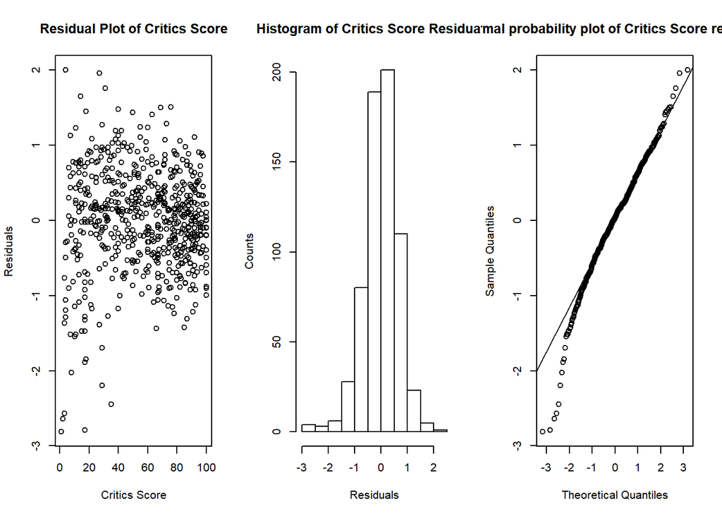

```r
par(mfrow=c(1,3))
 #residuals plot x=critics_score
plot(final_model$residuals~movies$critics_score, main="Residual Plot of Critics Score", xlab="Critics Score", ylab="Residuals")

hist(final_model$residuals,main="Histogram of Critics Score Residuals", xlab="Residuals", ylab="Counts") #histogram of Critics Score residuals
qqnorm(final_model$residuals, main="Normal probability plot of Critics Score residuals") # Normal QQ plot of residuals
qqline(final_model$residuals)
```

The summary of final_model has a p-value <2.2e-16, which is small enough to yield a statistically meaningful model.The residual plot and histogram show nearly random distribution around 0 and constant variance, indicating that our model is reliable.

## Improvement of our model

We can see from the adjusted R^s of all selected variables, the 2nd largest is contributed by “genre”. Our dataset classifies genre as action, comedy, documentary, drama, etc. Many films are crossed listed in two or more genres. And classifying the film in different genres will yield significantly different ratings. Take the example of 2014 film Birdman, which is classified as comedy and drama in IMDB.

```r
movies%>%
  group_by(genre)%>%
  summarise(n())

# predict the IMDB rating of Birdman in Drama
drama_birdman<- data.frame(critics_score=92, title_type="Feature Film",genre="Drama", best_pic_nom="no", best_dir_win="yes",top200_box="no" )

paste ("the predicted IMDB rating of Birdman in Drama is", predict(final_model, drama_birdman))

# predict the IMDB rating of Birdman in Comedy
comedy_birdman<- data.frame(critics_score=92, title_type="Feature Film",genre="Comedy", best_pic_nom="no", best_dir_win="yes",top200_box="no" )
paste ("the predicted IMDB rating of Birdman in Comedy is", predict(final_model, comedy_birdman))
```

```
## # A tibble: 11 x 2
##    genre                     `n()`
##    <fct>                     <int>
##  1 Action & Adventure           65
##  2 Animation                     9
##  3 Art House & International    14
##  4 Comedy                       87
##  5 Documentary                  51
##  6 Drama                       305
##  7 Horror                       23
##  8 Musical & Performing Arts    12
##  9 Mystery & Suspense           59
## 10 Other                        16
## 11 Science Fiction & Fantasy     9
## [1] "the predicted IMDB rating of Birdman in Drama is 7.55001931050493"
## [1] "the predicted IMDB rating of Birdman in Comedy is 7.1845315691553"
```

The predicted IMDB rating of Birdman in Drama is 7.6 and in Comedy is 7.2. The Drama rating is close to its IMDB Rating of 7.7.

We need more comprehensive classification of genre to better predict the IMDB ratings of movies.